# 第3章 图形初阶

武汉大学经济与管理学院  
刘开军 博士  
Email: kjliu@whu.edu.cn

## 图形初阶

R一共有4套不同的绘图系统，包括基本图形系统、grid、 lattice、 ggplot2。

作为基础，我们从R的基本图形系统讲起。

一个例子：

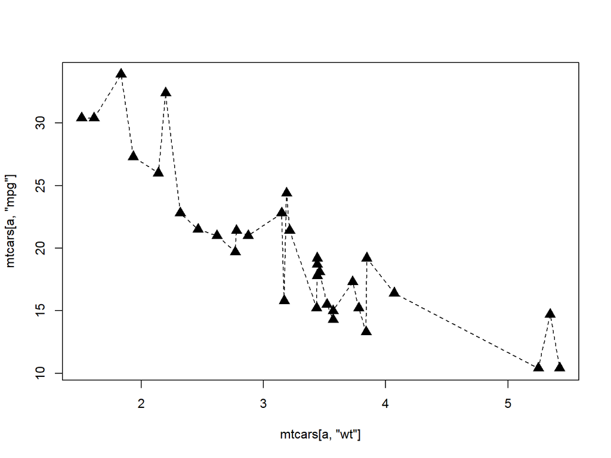

## 函数`plot()`

绘制基本图形最常用的函数是`plot()`，用于绘制点线图，语法为；

plot(x, y, param1=value1, param2=value2, …)

其中，x和y是要数据点的横坐标和纵坐标的向量，之后的参数用来指定图形的各种特征。

最常用的参数：

| 参数名 | 取值 |
| --- | --- |
| type | type=“l”表示只绘制折线；type=“p”表示只绘制点； type=“b”表示先绘制线再绘制点；type=“o”表示先绘制点再绘制线； type=“s”或type=“S”表示绘制阶梯图；type=“n”表示不绘制任何图形； |
| lty | 表示折线的线型，可取1~6； |
| lwd | 表示折线的宽度 |
| pch | 表示点的符号，可取0~25 |
| cex | 表示点的大小。cex小于1表示缩小，cex大于1表示放大。默认值为cex=1 |
| col | 表示点和线的颜色(color) |
| bg | 表示点的背景色(backgroud)。仅pch=21~25的点有背景色。 |

| 参数名 | 取值 |
| --- | --- |
| type | type=“l”表示只绘制折线；type=“p”表示只绘制点； type=“b”表示先绘制线再绘制点；type=“o”表示先绘制点再绘制线； type=“s”或type=“S”表示绘制阶梯图；type=“n”表示不绘制任何图形； |
| lty | 表示折线的线型，可取1~6； |
| lwd | 表示折线的宽度 |
| pch | 表示点的符号，可取0~25 |
| cex | 表示点的大小。cex小于1表示缩小，cex大于1表示放大。默认值为cex=1 |
| col | 表示点和线的颜色(color) |
| bg | 表示点的背景色(backgroud)。仅pch=21~25的点有背景色。 |

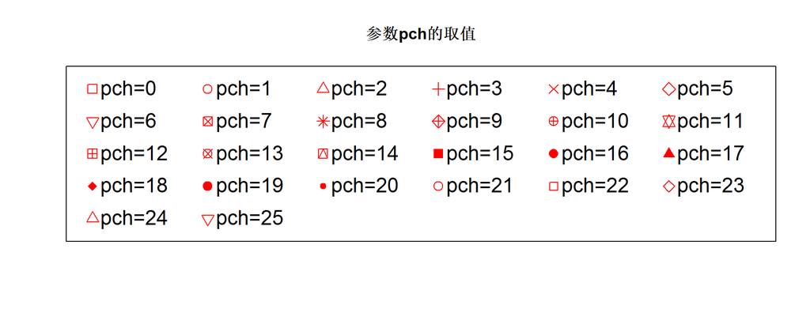

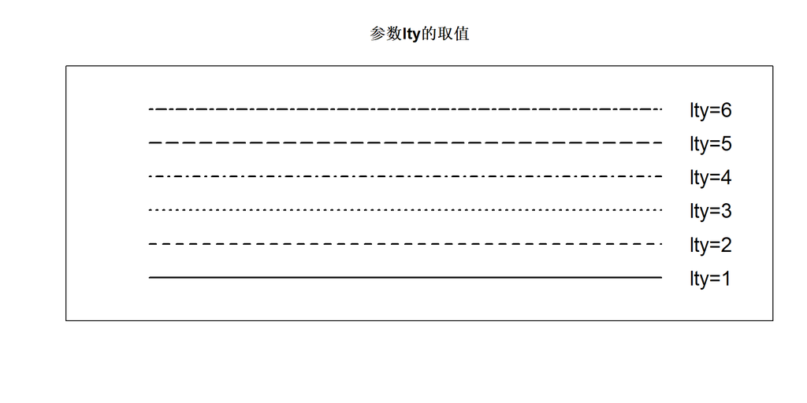

DIY：用R自带的数据框`cars`来绘制图形。

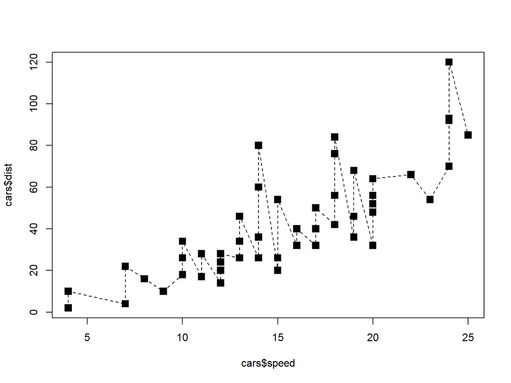

```r
plot(cars$speed, cars$dist, type="o", lty=2, pch=15, cex=1.5)
```

## 函数`plot()`的其他常用参数

| 参数名 | 取值 |
| --- | --- |
| main | 表示图的标题（标注在图的上方） |
| sub | 表示图的副标题（标注在图的下方） |
| xlab、ylab | 横轴、纵轴的标注 |
| xlim、ylim | 横轴、纵轴的取值范围，例如xlim=c(0, 100) |
| col | 表示点和线的颜色(color) |
| col.axis | 坐标轴的颜色 |
| col.lab | 坐标轴标注的颜色 |
| col.main | 图的主标题的颜色 |
| col.sub | 图的副标题的颜色 |
| cex | 点的大小。cex小于1表示缩小，cex大于1表示放大。默认值为cex=1 |
| cex.axis | 坐标轴刻度文本的大小 |
| cex.lab | 坐标轴标注文本的大小 |
| cex.main | 图的主标题文本的大小 |
| cex.sub | 图的副标题文本的大小 |
| font | 文本的字体样式。默认为1表示正常字体，2表示粗体，3表示斜体，4表示粗斜体 |
| font.axis | 坐标轴刻度文本的字体样式 |
| font.lab | 坐标轴标注文本的字体样式 |
| font.main | 图的主标题文本的字体样式 |
| font.sub | 图的副标题文本的字体样式 |
| family | 文本的字体簇，标准的取值为`"serif", "sans", "mono"`之一 |

DIY：制作一份较完整的点线图。

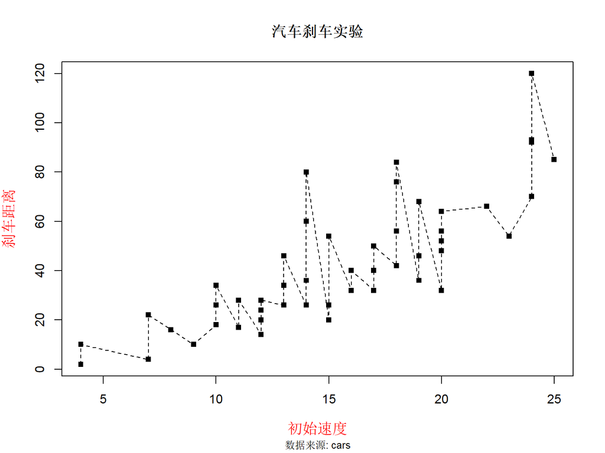

```r
plot(cars$speed, cars$dist, type="o", lty=2, pch=15, cex=0.9,
     xlab="初始速度", ylab="刹车距离", cex.lab=1.2, col.lab="red",
     main="汽车刹车实验", sub="数据来源: cars", cex.sub=0.8)
```

## 其他图元

函数`plot()`可以完成主体图形的绘制，我们还可以继续向图形添加文本、点、线等图元。

常用的图元函数

| 图元 | 函数 |
| --- | --- |
| 点和线 | points(x, y, type=“p”, …) |
| 点和线 | lines(x, y, type=“l”, …) |
| 文本 | text(x, y, labels, …) |
| 辅助线 | abline(a, b, h, v, …) |
| 网格线 | grid(nx, ny, …) |
| 图例 | legend(x, y, lengend, …) |
| 图的标题 | title(main, sub, xlab, ylab) |

以上图元函数会在当前坐标系统上绘图，因此当前必须要存在一个坐标系统（通常是用plot()生成）。

点和线

函数`points()`和`lines()`都可以绘制点和线（由参数type的值来控制），其参数与`plot()`的参数基本相同，区别在于：`points()`和`lines()`并不能生成坐标系统，它们只能在当前坐标系绘图，而`plot()`会生成一个新的坐标系统，然后绘制点和线。因此，`point()`和`lines()`只能在当前有坐标系统的情况下使用。

`points()`与`lines()`的区别在于：point()的参数type默认取`type="p"`，而lines()的参数type默认取`type="l"`。

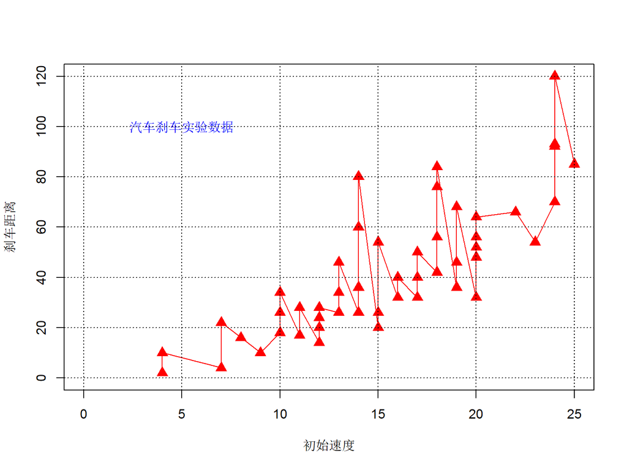

```r
plot(0,0, type="n", xlim=c(0,25), ylim=c(0, 120), xlab="初始速度", ylab="刹车距离")  #生成一个空的坐标系统
points(cars$speed, cars$dist, type="o", col="red", pch=17, cex=1.5)  #绘制点
text(5, 100, "汽车刹车实验数据", col="blue")
abline(v=seq(0,25, 5), lty=3)
abline(h=seq(0, 120, 20), lty=3)
```

文本

绘制文本的函数：

text(x, y, labels, adj, pos, cex, col, font)

各参数取值为：

[output not shown]

| 参数 | 说明 |
| --- | --- |
| x, y | 坐标点，该点是绘制文本的基准定位点 |
| labels | 文本字符串 |
| adj | 在[0, 1]上取值的1个值（或2个值），用于指定文本x方向（或y方向）的调整量。(0, 0)表示把定位点放在文本框的(0, 0)点，即左下角；(1, 1)表示把定位点放在文本框的(1, 1)点，即右上角。默认值为(0.5, 0.5) |
| cex | 文本的大小，默认为cex=1。小于1表示缩小，大于1表示放大 |
| col | 文本的颜色 |
| font | 字体样式，默认为1表示正常字体，2表示粗体，3表示斜体，4表示粗斜体 |
| family | 文本的字体簇，标准的取值为`"serif", "sans", "mono"`之一 |

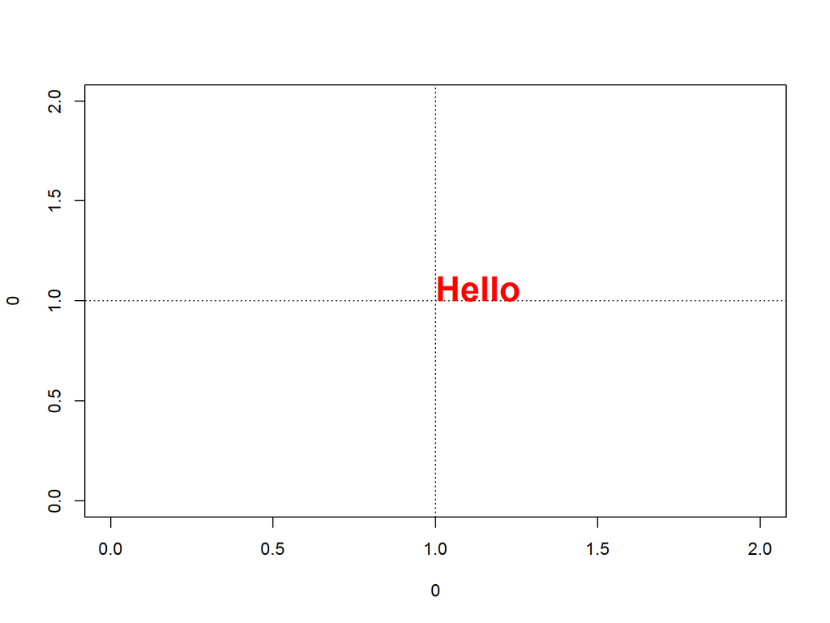

```r
plot(0, 0, type="n", xlim=c(0, 2), ylim=c(0, 2))
abline(v=1, h=1, lty=3)
text(1, 1, "Hello", adj=c(0, 0), cex=2, col="red", font=2)
```

辅助线

绘制水平、垂直辅助线的函数

abline(h=yvalues, v=xvalues, col, lty, lwd)

其中，参数h用于指定水平线，参数v用于指定垂直线，它们都可以取向量，表示同时绘制多条辅助线。

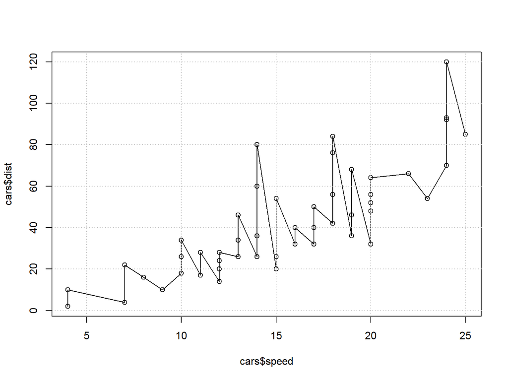

```r
plot(cars$speed, cars$dist, type="o")
abline(h=seq(0, 120, 20), v=seq(0, 25, 5), lty=3, col="gray")
```

函数abline()的另一种用法是绘制一条斜线，语法为：

abline(a, b, …)

其中，a为截距，b为斜率，即绘制直线$y=a+bx$。

```r
lm(dist~speed, cars)  #做一个线性回归
```

```
##
## Call:
## lm(formula = dist ~ speed, data = cars)
##
## Coefficients:
## (Intercept)        speed
##     -17.579        3.932
```

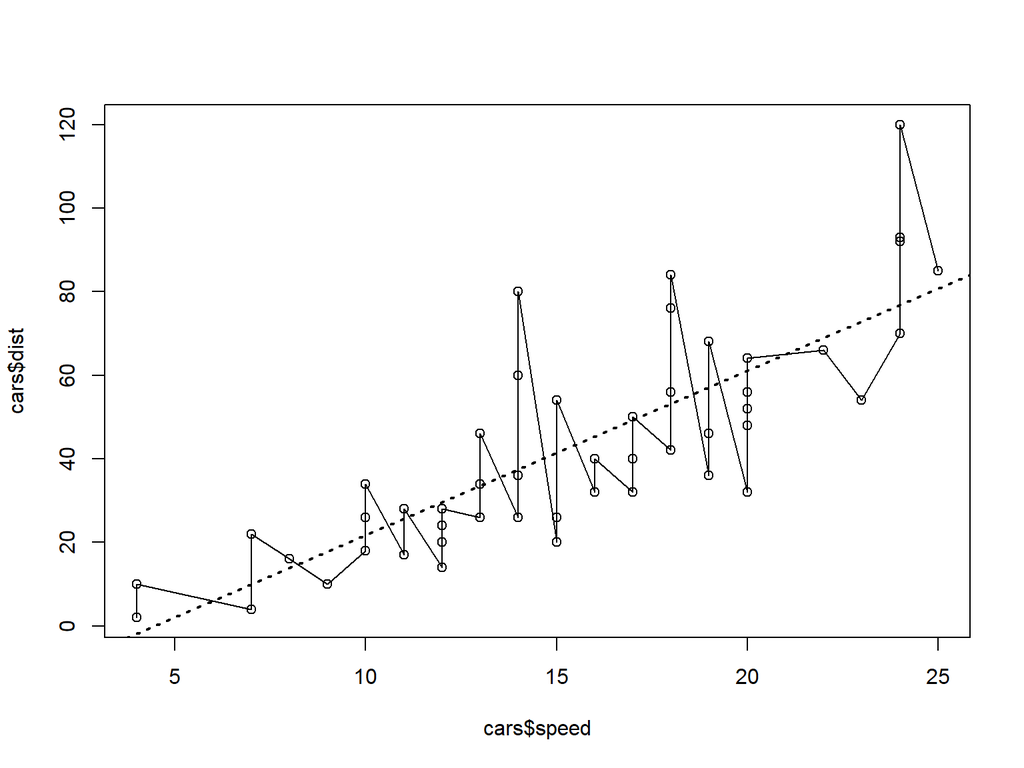

```r
plot(cars$speed, cars$dist, type="o")
abline(-17.579, 3.932, lty=3, lwd=2)
```

网格线

专门用于绘制网格线的函数：

grid(nx=NULL, ny=nx, col=“lightgray”, lty=“dotted”, lwd=par(“lwd”), equilogs=TRUE)

其中，nx设置水平网格的数目，ny设置垂直网格的数目；equilogs默认为TRUE，表示当坐标取对数后，仍使用等距的网格线，若为FALSE表示根据对数函数使用不等距网格线。

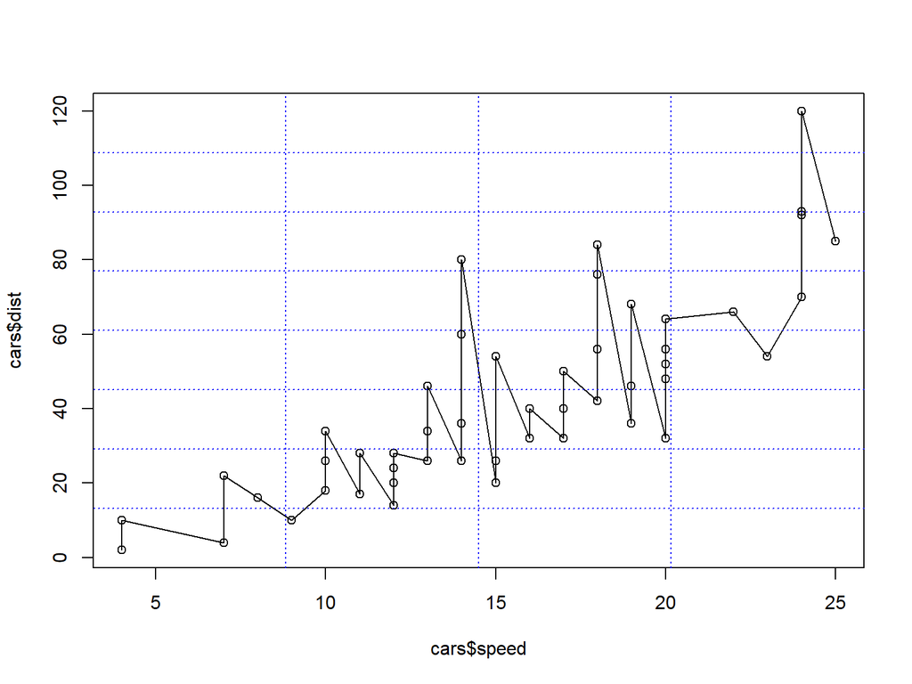

```r
plot(cars$speed, cars$dist, type="o")
grid(nx=4, ny=8, lwd=1, col="blue")
```

图例

使用legend()来绘制图例，该函数的常用参数为：

| 参数 | 说明 |
| --- | --- |
| x, y | 设置图例的位置（默认为左上角），可以是坐标值，也可使用“bottomright”, “bottomleft”, “topleft”, “topright”, “left”, “right”, “top”, “bottom”, “center”等关键字 |
| inset | 当图例位置使用关键字指定时，inset表示图例与坐标轴的间距。取值为小数，以坐标系的尺寸为单位1 |
| legend | 字符串向量，表示每个图例的标注文字 |
| pch, pt.cex, pt.bg, lty, lwd, col | 皆为向量，表示每个图例的点和线 |
| title | 图例的标题 |

| 参数 | 说明 |
| --- | --- |
| x, y | 设置图例的位置（默认为左上角），可以是坐标值，也可使用“bottomright”, “bottomleft”, “topleft”, “topright”, “left”, “right”, “top”, “bottom”, “center”等关键字 |
| inset | 当图例位置使用关键字指定时，inset表示图例与坐标轴的边距。取值为小数，以坐标系的尺寸为单位1 |
| legend | 字符串向量，表示每个图例的标注文字 |
| pch, pt.cex, pt.bg, lty, lwd, col | 皆为向量，表示每个图例的点和线 |
| title | 图例的标题 |

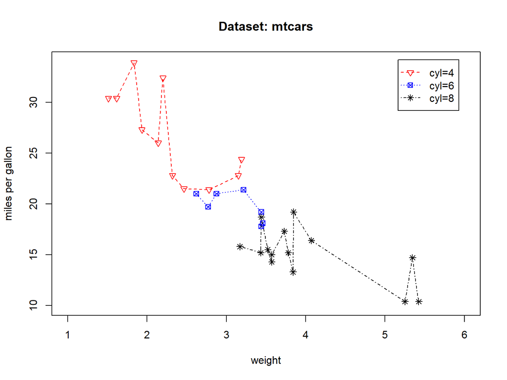

```r
mydata <- mtcars[order(mtcars$wt),]
attach(mydata)
plot(0, 0, type="n", xlim=c(1, 6), ylim=c(10, 34),
     main="Dataset: mtcars", xlab="weight", ylab="miles per gallon")
points(wt[cyl==4], mpg[cyl==4], type="o", pch=6, lty=2, col="red")
points(wt[cyl==6], mpg[cyl==6], type="o", pch=7, lty=3, col="blue")
points(wt[cyl==8], mpg[cyl==8], type="o", pch=8, lty=4, col="black")
legend("topright", inset=c(0.05, 0.03),
       legend=c("cyl=4", "cyl=6", "cyl=8"),
       pch=c(6, 7, 8), lty=c(2, 3, 4), col=c("red", "blue", "black"))
```

```r
detach(mydata)
```

图的标题

图的标题使用函数`title(main, sub, xlab, ylab)`设置，其中main是图的主标题，显示在图的正上方；subs是图的副标题，显示在图的正下方；xlab是x轴的标注，ylab是y轴的标注。这四个参数可以是简单的字符串，或者是list(text, font, col, cex,…)。

注意，用title()设置标题，只是在相应位置上绘制一段文本，并不会删掉之前用plot()绘制的标题。

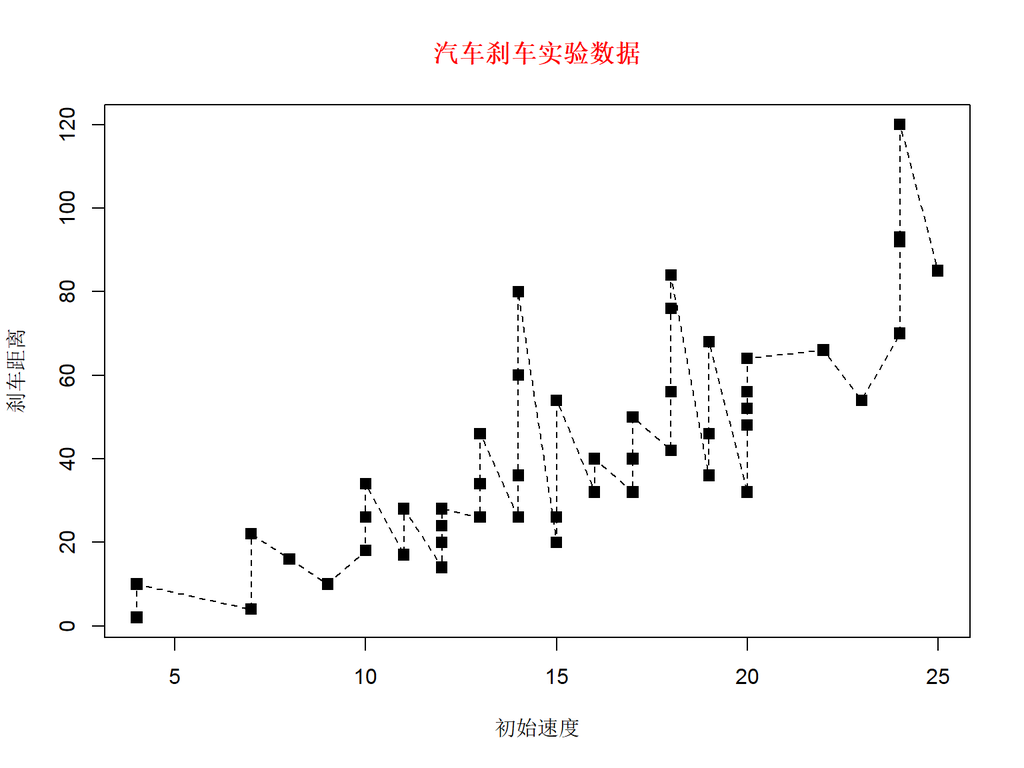

```r
plot(cars$speed, cars$dist, type="o", lty=2, pch=15, cex=1.2, xlab="", ylab="") #将xlab和ylab设置为空
title(main=list("汽车刹车实验数据", col="red"), xlab="初始速度", ylab="刹车距离")
```

## Do It Yourself

其他图元函数

| 功能 | 函数 |
| --- | --- |
| 箭头 | arrows(x0, y0, x1, y1, angle, length, lty, lwd, col, …) |
| 线段 | segment(x0, y0, x1, y1, lty, lwd, col, …) |
| 文本 | mtext(text, side=3, line=0, …) |
| 轴须图 | rug(x, ticksize=0.03, side=1, lwd, col, …) |
| 坐标轴 | axis(side, at=NULL, labels=TRUE, tick=TRUE, …) |

## 图形矩阵

R base的图形系统有很多参数(parameters)，例如，参数mar和mai表示图形的边界宽度，参数font表示文本的字体，参数lty表示线型，参数pch表示点的符号。当一个绘图函数（例如plot()）执行时，会合并图形系统的参数与程序员指定的参数，由此决定一张图的所有细节。所以，我们在绘图时，只需要指定少数几个我们关注的参数，其他参数使用图形系统的参数值就可以了。

设置图形系统参数的函数是：

par(tag1=value1, tag2=value2, …)

其中，tag1、tag2等是参数名，value1、value2等是参数值。注意，用`par()`设置的参数会对所有的绘图函数起作用，也就是说，调用`par()`设置图形参数相当于修改了图形参数的默认值。

图形系统的参数有些是可修改的，有些是只读的，`par(no.readonly=TRUE)`可得到所有可修改的图形参数的当前值。一般的绘图流程是：先保存`par(no.readonly=TRUE)`的返回值，然后修改图形系统的参数，最后恢复原设置，即：

```r
#首先，保存默认设置
old.par <- par(no.readonly=TRUE)

#修改图形系统的参数，进行绘图
par(font=4, lty=2, pch=17)   #修改图形系统的参数
plot(...)
.......

#绘图结束后，恢复原设置
par(old.par)
```

DIY：请查看函数par()的帮助文档，了解图形系统的各种参数。

在图形系统众多的参数中，mfrow和mfcol用于设置图形系统的子图矩阵。`mfrow=c(m, n)`表示把画布划分为m行n列的矩阵，绘图时逐行从左到右作图；`mfcol=c(m, n)`也表示把画布划分为m行n列的矩阵，但绘图时逐列从上到下作图。

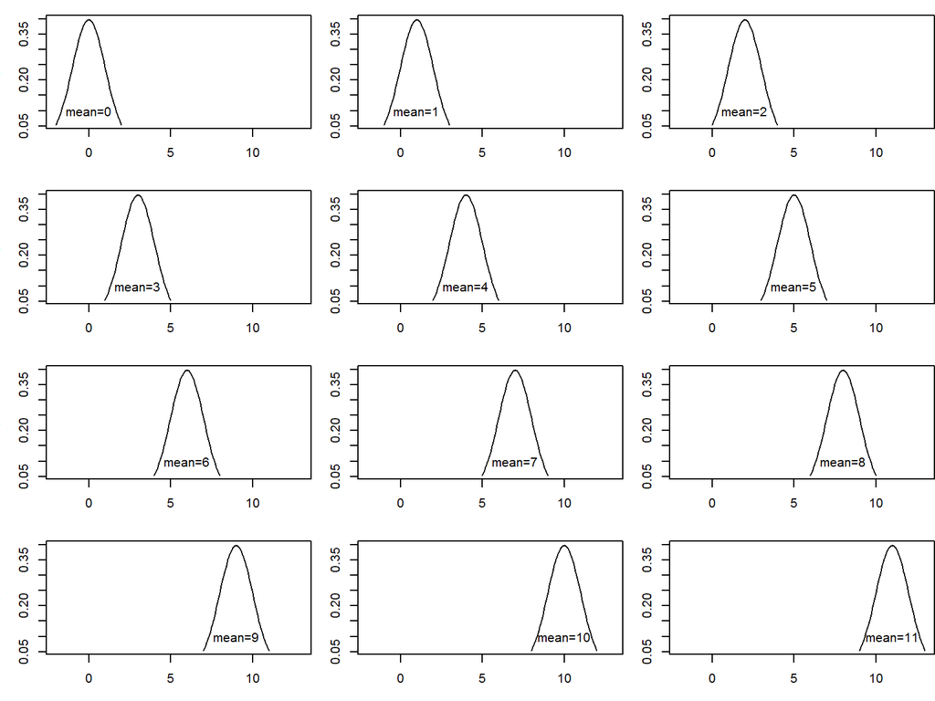

```r
#绘制一幅4*3的图形矩阵

old.par <- par(no.readonly=TRUE)  #保存原设置

par(mfrow=c(4, 3), mar=c(3,3,1,0))  #需要用mar把图形边界调小，否则会因为图形太多发生错误

for(m in 0:3)
{
  for(n in 0:2)
  {
    x <- seq(m*3+n-2, m*3+n+2, 0.1)
    y <- dnorm(x, mean=m*3+n, sd=1)
    plot(x, y, type="l", xlim=c(-2, 13))
    text(m*3+n, 0.1, paste("mean=", m*3+n, sep=""))
  }
}
```

```r
par(old.par)  #恢复原设置
```

如果使用了mfrow或mfcol设置了图形矩阵，默认情况下，会逐个绘制每个子图，但是我们也可以使用mfg=c(i, j)指定在第i行第j列绘图。

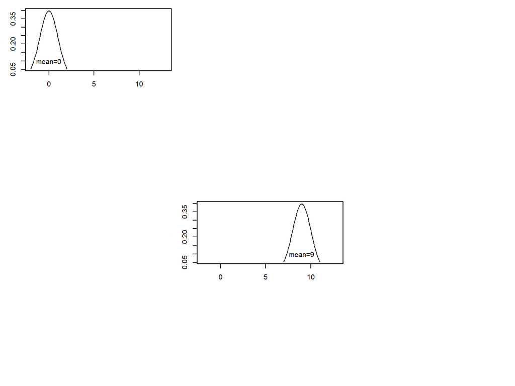

```r
old.par <- par(no.readonly=TRUE)  #保存原设置

par(mfrow=c(4, 3), mar=c(3,3,1,0))  #需要用mar把图形边界调小，否则会因为图形太多发生错误

x <- seq(-2, 2, 0.1)
y <- dnorm(x, mean=0, sd=1)
plot(x, y, type="l", xlim=c(-2, 13))
text(0, 0.1, "mean=0")

par(mfg=c(3, 2))  #在第3行第2列绘图
x <- seq(9-2, 9+2, 0.1)
y <- dnorm(x, mean=9, sd=1)
plot(x, y, type="l", xlim=c(-2, 13))
text(9, 0.1, "mean=9")

par(old.par)  #恢复原设置
```

常见问题

在使用子图矩阵时，可能会遇到`"Error in plot.new() : figure margins too large"`错误，这是因为画布太小而子图的边距太大，画布不能容纳所有的子图。我们可以把每幅子图的边距调小，从而避免这个错误。与图形尺寸有关的参数有三个：

[output not shown]

## 自学内容

- 保存图形
- 图形的组合与布局，函数layout()
- `plot()`的其他参数